# Practical Machine Learning Course Project

Anton Hesse

6/21/2020

Practical Machine Learning Course Project

GitHub Repo: https://github.com/ahesse2567/practicalmachinelearning

## Background Information

Physical activity monitors such as heart rate monitors have been commonplace for a long while. However, newer devices may have the capability to analyze weightlifting exercises to determine the quality of each repetition. That is, was the person performing the weightlifting exercise doing it incorrectly because of improper technique knowledge? Or, are they succumbing to fatigue and making improper compensations? This may be useful for both teaching exercises, assessing and evaluating training, and predicting injury risk.

In this particular dataset, particpants were performing bicep curls in the correct and in several incorrect manners. Full information on the study and the dataset can be found here: http://web.archive.org/web/20161224072740/http:/groupware.les.inf.puc-rio.br/har#related_publications. Additional information is found below in the assignment description.

## Assignment description

"What you should submit:

The goal of your project is to predict the manner in which they did the exercise. This is the “classe” variable in the training set. You may use any of the other variables to predict with. You should create a report describing how you built your model, how you used cross validation, what you think the expected out of sample error is, and why you made the choices you did. You will also use your prediction model to predict 20 different test cases."

## Reproducibility

The following is the list of packages and the seed so others can verify the results

```r
# load packages and set the seed
library(tidyverse); library(caret); library(magrittr); library(car); library(corrplot)
library(randomForest); library(rattle);
set.seed(1234)
```

## Setting up the data

First, we need to import the data from the URL. Next we will split the training data into training and testing datasets. The “testing” url will serve as the validation set.

```r
# create training and testing sets
training <- read.csv("https://d396qusza40orc.cloudfront.net/predmachlearn/pml-training.csv")
inTrain <- createDataPartition(training$classe, p = 0.7, list = FALSE)
training <- training[inTrain,]
testing <- training[-inTrain,]

dim(training)
```

```
## [1] 13737   160
```

```r
dim(testing)
```

```
## [1] 4124  160
```

```r
# create validation set
validation <- read.csv("https://d396qusza40orc.cloudfront.net/predmachlearn/pml-testing.csv")
dim(validation)
```

```
## [1]  20 160
```

## Exploratory Data Analysis and Data Cleaning

```r
summary(training)
```

```
##        X            user_name    raw_timestamp_part_1 raw_timestamp_part_2
##  Min.   :    2   adelmo  :2729   Min.   :1.322e+09    Min.   :   294
##  1st Qu.: 4925   carlitos:2195   1st Qu.:1.323e+09    1st Qu.:252398
##  Median : 9814   charles :2468   Median :1.323e+09    Median :494703
##  Mean   : 9810   eurico  :2145   Mean   :1.323e+09    Mean   :500149
##  3rd Qu.:14694   jeremy  :2370   3rd Qu.:1.323e+09    3rd Qu.:750646
##  Max.   :19622   pedro   :1830   Max.   :1.323e+09    Max.   :998750
##
##           cvtd_timestamp new_window    num_window      roll_belt
##  28/11/2011 14:14:1060   no :13453   Min.   :  1.0   Min.   :-28.90
##  05/12/2011 11:24:1058   yes:  284   1st Qu.:221.0   1st Qu.:  1.10
##  30/11/2011 17:11:1015               Median :424.0   Median :113.00
##  05/12/2011 11:25:1001               Mean   :430.7   Mean   : 64.45
##  02/12/2011 14:57: 968               3rd Qu.:644.0   3rd Qu.:123.00
##  02/12/2011 13:34: 965               Max.   :864.0   Max.   :162.00
##  (Other)         :7670
##    pitch_belt          yaw_belt       total_accel_belt kurtosis_roll_belt
##  Min.   :-54.9000   Min.   :-179.00   Min.   : 0.00             :13453
##  1st Qu.:  1.7500   1st Qu.: -88.30   1st Qu.: 3.00    #DIV/0!  :    9
##  Median :  5.2800   Median : -13.00   Median :17.00    -1.908453:    2
##  Mean   :  0.2866   Mean   : -10.95   Mean   :11.32    -0.021024:    1
##  3rd Qu.: 15.2000   3rd Qu.:  14.00   3rd Qu.:18.00    -0.025513:    1
##  Max.   : 60.3000   Max.   : 179.00   Max.   :29.00    -0.033935:    1
##                                                        (Other)  :  270
##  kurtosis_picth_belt kurtosis_yaw_belt skewness_roll_belt skewness_roll_belt.1
##           :13453            :13453              :13453             :13453
##  #DIV/0!  :   23     #DIV/0!:  284     #DIV/0!  :    8    #DIV/0!  :   23
##  -0.150950:    3                       0.000000 :    3    0.000000 :    4
##  7.770402 :    3                       0.422463 :    2    -3.072669:    3
##  -0.684748:    2                       -0.003095:    1    -0.587156:    2
##  -0.686349:    2                       -0.014020:    1    -0.733570:    2
##  (Other)  :  251                       (Other)  :  269    (Other)  :  250
##  skewness_yaw_belt max_roll_belt     max_picth_belt   max_yaw_belt
##         :13453     Min.   :-94.300   Min.   : 3.00          :13453
##  #DIV/0!:  284     1st Qu.:-88.000   1st Qu.: 5.00   -1.4   :   22
##                    Median : -5.100   Median :18.00   -1.1   :   19
##                    Mean   : -5.107   Mean   :13.01   -0.9   :   17
##                    3rd Qu.: 20.025   3rd Qu.:19.00   -1.2   :   17
##                    Max.   :177.000   Max.   :30.00   -1.3   :   16
##                    NA's   :13453     NA's   :13453   (Other):  193
```

[output cut: 281 more lines]

```
##  Min.   : -6.62000   Min.   : -8.0900   Min.   :-498.00   Min.   :-595.0
##  1st Qu.: -1.46000   1st Qu.: -0.1800   1st Qu.:-176.00   1st Qu.:  57.0
##  Median :  0.03000   Median :  0.0800   Median : -57.00   Median : 201.0
##  Mean   :  0.08933   Mean   :  0.1575   Mean   : -61.14   Mean   : 163.7
##  3rd Qu.:  1.64000   3rd Qu.:  0.4900   3rd Qu.:  77.00   3rd Qu.: 313.0
##  Max.   :311.00000   Max.   :231.0000   Max.   : 389.00   Max.   : 923.0
##
##  accel_forearm_z   magnet_forearm_x  magnet_forearm_y magnet_forearm_z classe
##  Min.   :-446.00   Min.   :-1280.0   Min.   :-896.0   Min.   :-966.0   A:3906
##  1st Qu.:-182.00   1st Qu.: -615.0   1st Qu.:  -3.0   1st Qu.: 186.0   B:2658
##  Median : -40.00   Median : -376.0   Median : 590.0   Median : 509.0   C:2396
##  Mean   : -55.51   Mean   : -311.2   Mean   : 378.9   Mean   : 391.6   D:2252
##  3rd Qu.:  26.00   3rd Qu.:  -73.0   3rd Qu.: 736.0   3rd Qu.: 652.0   E:2525
##  Max.   : 291.00   Max.   :  672.0   Max.   :1480.0   Max.   :1090.0
##
```

We have to deal with NA’s, blanks, and #DIV0!’s. We will identify how many NA values there are first.

```r
(naList <- colnames(training)[colSums(is.na(training)) > 0])
```

```
##  [1] "max_roll_belt"            "max_picth_belt"
##  [3] "min_roll_belt"            "min_pitch_belt"
##  [5] "amplitude_roll_belt"      "amplitude_pitch_belt"
##  [7] "var_total_accel_belt"     "avg_roll_belt"
##  [9] "stddev_roll_belt"         "var_roll_belt"
## [11] "avg_pitch_belt"           "stddev_pitch_belt"
## [13] "var_pitch_belt"           "avg_yaw_belt"
## [15] "stddev_yaw_belt"          "var_yaw_belt"
## [17] "var_accel_arm"            "avg_roll_arm"
## [19] "stddev_roll_arm"          "var_roll_arm"
## [21] "avg_pitch_arm"            "stddev_pitch_arm"
## [23] "var_pitch_arm"            "avg_yaw_arm"
## [25] "stddev_yaw_arm"           "var_yaw_arm"
## [27] "max_roll_arm"             "max_picth_arm"
## [29] "max_yaw_arm"              "min_roll_arm"
```

[output cut: 19 more lines]

```r
(noNAList <- colnames(training)[colSums(is.na(training)) == 0])
```

```
##  [1] "X"                       "user_name"
##  [3] "raw_timestamp_part_1"    "raw_timestamp_part_2"
##  [5] "cvtd_timestamp"          "new_window"
##  [7] "num_window"              "roll_belt"
##  [9] "pitch_belt"              "yaw_belt"
## [11] "total_accel_belt"        "kurtosis_roll_belt"
## [13] "kurtosis_picth_belt"     "kurtosis_yaw_belt"
## [15] "skewness_roll_belt"      "skewness_roll_belt.1"
## [17] "skewness_yaw_belt"       "max_yaw_belt"
## [19] "min_yaw_belt"            "amplitude_yaw_belt"
## [21] "gyros_belt_x"            "gyros_belt_y"
## [23] "gyros_belt_z"            "accel_belt_x"
## [25] "accel_belt_y"            "accel_belt_z"
## [27] "magnet_belt_x"           "magnet_belt_y"
## [29] "magnet_belt_z"           "roll_arm"
```

[output cut: 32 more lines]

```r
a <- sapply(training, function(x) sum(is.na(x))/nrow(training))
b <- which(a > 0)
a[b]
```

```
##            max_roll_belt           max_picth_belt            min_roll_belt
##                0.9793259                0.9793259                0.9793259
##           min_pitch_belt      amplitude_roll_belt     amplitude_pitch_belt
##                0.9793259                0.9793259                0.9793259
##     var_total_accel_belt            avg_roll_belt         stddev_roll_belt
##                0.9793259                0.9793259                0.9793259
##            var_roll_belt           avg_pitch_belt        stddev_pitch_belt
##                0.9793259                0.9793259                0.9793259
##           var_pitch_belt             avg_yaw_belt          stddev_yaw_belt
##                0.9793259                0.9793259                0.9793259
##             var_yaw_belt            var_accel_arm             avg_roll_arm
##                0.9793259                0.9793259                0.9793259
##          stddev_roll_arm             var_roll_arm            avg_pitch_arm
##                0.9793259                0.9793259                0.9793259
##         stddev_pitch_arm            var_pitch_arm              avg_yaw_arm
##                0.9793259                0.9793259                0.9793259
##           stddev_yaw_arm              var_yaw_arm             max_roll_arm
##                0.9793259                0.9793259                0.9793259
##            max_picth_arm              max_yaw_arm             min_roll_arm
##                0.9793259                0.9793259                0.9793259
##            min_pitch_arm              min_yaw_arm       amplitude_roll_arm
##                0.9793259                0.9793259                0.9793259
##      amplitude_pitch_arm        amplitude_yaw_arm        max_roll_dumbbell
##                0.9793259                0.9793259                0.9793259
##       max_picth_dumbbell        min_roll_dumbbell       min_pitch_dumbbell
##                0.9793259                0.9793259                0.9793259
##  amplitude_roll_dumbbell amplitude_pitch_dumbbell       var_accel_dumbbell
##                0.9793259                0.9793259                0.9793259
##        avg_roll_dumbbell     stddev_roll_dumbbell        var_roll_dumbbell
##                0.9793259                0.9793259                0.9793259
##       avg_pitch_dumbbell    stddev_pitch_dumbbell       var_pitch_dumbbell
##                0.9793259                0.9793259                0.9793259
##         avg_yaw_dumbbell      stddev_yaw_dumbbell         var_yaw_dumbbell
##                0.9793259                0.9793259                0.9793259
##         max_roll_forearm        max_picth_forearm         min_roll_forearm
##                0.9793259                0.9793259                0.9793259
##        min_pitch_forearm   amplitude_roll_forearm  amplitude_pitch_forearm
##                0.9793259                0.9793259                0.9793259
##        var_accel_forearm         avg_roll_forearm      stddev_roll_forearm
##                0.9793259                0.9793259                0.9793259
##         var_roll_forearm        avg_pitch_forearm     stddev_pitch_forearm
##                0.9793259                0.9793259                0.9793259
##        var_pitch_forearm          avg_yaw_forearm       stddev_yaw_forearm
##                0.9793259                0.9793259                0.9793259
##          var_yaw_forearm
##                0.9793259
```

98% of values in columns w/ NA values are NA values. This is too many to impute and we would therefore exclude those columns.

```r
training <- training[, apply(training, 2, function(x) !any(is.na(x)))]
testing <- testing[, apply(testing, 2, function(x) !any(is.na(x)))]
validation <- validation[, apply(validation, 2, function(x) !any(is.na(x)))]
dim(training)
```

```
## [1] 13737    93
```

```r
dim(testing)
```

```
## [1] 4124   93
```

```r
dim(validation)
```

```
## [1] 20 60
```

There are also some predictors that appear to be for bookkeeping purposes only. We will identify and remove theose

```r
colnames(training)
```

```
##  [1] "X"                       "user_name"
##  [3] "raw_timestamp_part_1"    "raw_timestamp_part_2"
##  [5] "cvtd_timestamp"          "new_window"
##  [7] "num_window"              "roll_belt"
##  [9] "pitch_belt"              "yaw_belt"
## [11] "total_accel_belt"        "kurtosis_roll_belt"
## [13] "kurtosis_picth_belt"     "kurtosis_yaw_belt"
## [15] "skewness_roll_belt"      "skewness_roll_belt.1"
## [17] "skewness_yaw_belt"       "max_yaw_belt"
## [19] "min_yaw_belt"            "amplitude_yaw_belt"
## [21] "gyros_belt_x"            "gyros_belt_y"
## [23] "gyros_belt_z"            "accel_belt_x"
## [25] "accel_belt_y"            "accel_belt_z"
## [27] "magnet_belt_x"           "magnet_belt_y"
## [29] "magnet_belt_z"           "roll_arm"
```

[output cut: 32 more lines]

```r
training <- training[,-c(1:5)] # remove variables that are likely for bookkeeping only
str(training) # several variables need to be converted from factors into numeric
```

```
## 'data.frame':    13737 obs. of  88 variables:
##  $ new_window             : Factor w/ 2 levels "no","yes": 1 1 1 1 1 1 1 1 1 1 ...
##  $ num_window             : int  11 11 12 12 12 12 12 12 12 12 ...
##  $ roll_belt              : num  1.41 1.42 1.48 1.48 1.45 1.42 1.42 1.43 1.45 1.45 ...
##  $ pitch_belt             : num  8.07 8.07 8.05 8.07 8.06 8.09 8.13 8.16 8.17 8.18 ...
##  $ yaw_belt               : num  -94.4 -94.4 -94.4 -94.4 -94.4 -94.4 -94.4 -94.4 -94.4 -94.4 ...
##  $ total_accel_belt       : int  3 3 3 3 3 3 3 3 3 3 ...
##  $ kurtosis_roll_belt     : Factor w/ 397 levels "","-0.016850",..: 1 1 1 1 1 1 1 1 1 1 ...
##  $ kurtosis_picth_belt    : Factor w/ 317 levels "","-0.021887",..: 1 1 1 1 1 1 1 1 1 1 ...
##  $ kurtosis_yaw_belt      : Factor w/ 2 levels "","#DIV/0!": 1 1 1 1 1 1 1 1 1 1 ...
##  $ skewness_roll_belt     : Factor w/ 395 levels "","-0.003095",..: 1 1 1 1 1 1 1 1 1 1 ...
##  $ skewness_roll_belt.1   : Factor w/ 338 levels "","-0.005928",..: 1 1 1 1 1 1 1 1 1 1 ...
##  $ skewness_yaw_belt      : Factor w/ 2 levels "","#DIV/0!": 1 1 1 1 1 1 1 1 1 1 ...
##  $ max_yaw_belt           : Factor w/ 68 levels "","-0.1","-0.2",..: 1 1 1 1 1 1 1 1 1 1 ...
##  $ min_yaw_belt           : Factor w/ 68 levels "","-0.1","-0.2",..: 1 1 1 1 1 1 1 1 1 1 ...
```

[output cut: 74 more lines]

From looking at the structure of the data it’s clear that several variables are factors when they should be numeric.

```r
training[,-length(training)] %<>% # remove all but last variable since it's the classe
  mutate_if(is.factor,as.numeric)
str(training)
```

```
## 'data.frame':    13737 obs. of  88 variables:
##  $ new_window             : num  1 1 1 1 1 1 1 1 1 1 ...
##  $ num_window             : int  11 11 12 12 12 12 12 12 12 12 ...
##  $ roll_belt              : num  1.41 1.42 1.48 1.48 1.45 1.42 1.42 1.43 1.45 1.45 ...
##  $ pitch_belt             : num  8.07 8.07 8.05 8.07 8.06 8.09 8.13 8.16 8.17 8.18 ...
##  $ yaw_belt               : num  -94.4 -94.4 -94.4 -94.4 -94.4 -94.4 -94.4 -94.4 -94.4 -94.4 ...
##  $ total_accel_belt       : int  3 3 3 3 3 3 3 3 3 3 ...
##  $ kurtosis_roll_belt     : num  1 1 1 1 1 1 1 1 1 1 ...
##  $ kurtosis_picth_belt    : num  1 1 1 1 1 1 1 1 1 1 ...
##  $ kurtosis_yaw_belt      : num  1 1 1 1 1 1 1 1 1 1 ...
##  $ skewness_roll_belt     : num  1 1 1 1 1 1 1 1 1 1 ...
##  $ skewness_roll_belt.1   : num  1 1 1 1 1 1 1 1 1 1 ...
##  $ skewness_yaw_belt      : num  1 1 1 1 1 1 1 1 1 1 ...
##  $ max_yaw_belt           : num  1 1 1 1 1 1 1 1 1 1 ...
##  $ min_yaw_belt           : num  1 1 1 1 1 1 1 1 1 1 ...
```

[output cut: 74 more lines]

Changing the data from factor to numeric appeared to also resolve the NA’s and #DIV0!’s. Repeat for testing and validation sets

```r
testing <- testing[,-c(1:5)] # remove variables that are likely for bookkeeping only
testing[,-length(testing)] %<>% # remove all but last variable since it's the classe
  mutate_if(is.factor,as.numeric)

# repeat for validation
validation <- validation[,-c(1:5)] # remove variables that are likely for bookkeeping only
validation[,-length(validation)] %<>%
  mutate_if(is.factor,as.numeric)
```

Now we will examine how many variables have near zero variation because they likely wouldn’t contribute much information to the final model.

```r
names(training)[nearZeroVar(training)]
```

```
##  [1] "new_window"              "kurtosis_roll_belt"
##  [3] "kurtosis_picth_belt"     "kurtosis_yaw_belt"
##  [5] "skewness_roll_belt"      "skewness_roll_belt.1"
##  [7] "skewness_yaw_belt"       "max_yaw_belt"
##  [9] "min_yaw_belt"            "amplitude_yaw_belt"
## [11] "kurtosis_roll_arm"       "kurtosis_picth_arm"
## [13] "kurtosis_yaw_arm"        "skewness_roll_arm"
## [15] "skewness_pitch_arm"      "skewness_yaw_arm"
## [17] "kurtosis_roll_dumbbell"  "kurtosis_picth_dumbbell"
## [19] "kurtosis_yaw_dumbbell"   "skewness_roll_dumbbell"
## [21] "skewness_pitch_dumbbell" "skewness_yaw_dumbbell"
## [23] "max_yaw_dumbbell"        "min_yaw_dumbbell"
## [25] "amplitude_yaw_dumbbell"  "kurtosis_roll_forearm"
## [27] "kurtosis_picth_forearm"  "kurtosis_yaw_forearm"
## [29] "skewness_roll_forearm"   "skewness_pitch_forearm"
## [31] "skewness_yaw_forearm"    "max_yaw_forearm"
## [33] "min_yaw_forearm"         "amplitude_yaw_forearm"
```

```r
nzv <- nearZeroVar(training)
var(training[,nzv])
```

[output not shown]

[output cut: 470 more lines]

```
## skewness_roll_dumbbell             7.36710968
## skewness_pitch_dumbbell            7.19536918
## skewness_yaw_dumbbell              0.03621852
## max_yaw_dumbbell                   0.85926952
## min_yaw_dumbbell                   0.85926952
## amplitude_yaw_dumbbell             0.07193819
## kurtosis_roll_forearm              6.26806627
## kurtosis_picth_forearm             6.28107073
## kurtosis_yaw_forearm               0.03621852
## skewness_roll_forearm              5.85337795
## skewness_pitch_forearm             6.07201686
## skewness_yaw_forearm               0.03621852
## max_yaw_forearm                    0.51386309
## min_yaw_forearm                    0.51386309
## amplitude_yaw_forearm              0.06823049
```

```r
length(nzv) # 34 variables with nearZeroVar
```

```
## [1] 34
```

```r
training <- training[,-nzv] # remove variables with near zero variation
dim(training)
```

```
## [1] 13737    54
```

```r
# repeat for testing and validation sets
testing <- testing[,-nearZeroVar(testing)]
validation <- validation[,-nearZeroVar(validation)]
```

## Data Visualization

Now that the data is cleaned, we will correlate predictors to assess covariation

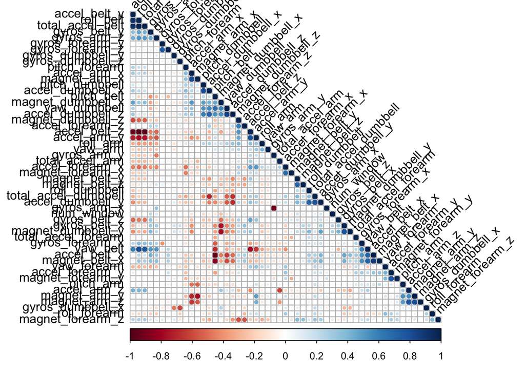

```r
corObj <- cor(testing[-length(testing)])

corrplot(corObj, type = "lower", order="hclust",
         tl.col="black", tl.srt = 45)
```

## Model Creation

We will test four models: 1. Classification and Regression Trees (CART) 2. Random Forests 3. Bagging 4. Boosting

1. Classification and Regression Trees (CART):

```r
modCART <- train(classe ~ ., data = training,
                 preProcess = c("center", "scale"), method = "rpart")
modCART
```

```
## CART
##
## 13737 samples
##    53 predictor
##     5 classes: 'A', 'B', 'C', 'D', 'E'
##
## Pre-processing: centered (53), scaled (53)
## Resampling: Bootstrapped (25 reps)
## Summary of sample sizes: 13737, 13737, 13737, 13737, 13737, 13737, ...
## Resampling results across tuning parameters:
##
##   cp          Accuracy   Kappa
##   0.03885668  0.5288540  0.38922997
##   0.06092971  0.4039172  0.18687397
##   0.11738379  0.3340619  0.07502825
##
## Accuracy was used to select the optimal model using the largest value.
## The final value used for the model was cp = 0.03885668.
```

2. Random Forests:

```r
train_Control <- trainControl(method = "cv", number = 3, verboseIter = FALSE)
modRF <- train(classe ~., data = training, preProcess = c("center", "scale"),
               method="rf", trControl = train_Control)
modRF
```

```
## Random Forest
##
## 13737 samples
##    53 predictor
##     5 classes: 'A', 'B', 'C', 'D', 'E'
##
## Pre-processing: centered (53), scaled (53)
## Resampling: Cross-Validated (3 fold)
## Summary of sample sizes: 9160, 9157, 9157
## Resampling results across tuning parameters:
##
##   mtry  Accuracy   Kappa
##    2    0.9919191  0.9897780
##   27    0.9962868  0.9953034
##   53    0.9945399  0.9930936
##
## Accuracy was used to select the optimal model using the largest value.
## The final value used for the model was mtry = 27.
```

Very high accuracy with random forests

3. Bagging:

```r
modBag <- train(classe ~., data = training, preProcess = c("center", "scale"),
                method = "treebag", trControl = train_Control)
```

4. Boosting:

```r
modBoosting <- train(classe ~ ., data=training, method = "gbm",
                     trControl = train_Control, verbose = FALSE)
modBoosting
```

```
## Stochastic Gradient Boosting
##
## 13737 samples
##    53 predictor
##     5 classes: 'A', 'B', 'C', 'D', 'E'
##
## No pre-processing
## Resampling: Cross-Validated (3 fold)
## Summary of sample sizes: 9158, 9158, 9158
## Resampling results across tuning parameters:
##
##   interaction.depth  n.trees  Accuracy   Kappa
##   1                   50      0.7571522  0.6921455
##   1                  100      0.8278372  0.7820792
##   1                  150      0.8699134  0.8353799
##   2                   50      0.8774842  0.8448023
##   2                  100      0.9355755  0.9184766
##   2                  150      0.9619276  0.9518276
##   3                   50      0.9344107  0.9169767
##   3                  100      0.9704448  0.9626024
##   3                  150      0.9853680  0.9814892
##
## Tuning parameter 'shrinkage' was held constant at a value of 0.1
##
## Tuning parameter 'n.minobsinnode' was held constant at a value of 10
## Accuracy was used to select the optimal model using the largest value.
## The final values used for the model were n.trees = 150, interaction.depth =
##  3, shrinkage = 0.1 and n.minobsinnode = 10.
```

Once again, very high accuracy, but not quite as high as random forests

## Estimating model accuracy with testing datasets and final prediction

```r
predict_CART <- predict(modCART, testing)
predict_RF <- predict(modRF, testing)
predict_Bag <- predict(modBag, testing)
predict_Boosting <- predict(modBoosting, testing)

(cm_CART <- confusionMatrix(testing$classe, predict_CART)) # only 50% correct
```

```
## Confusion Matrix and Statistics
##
##           Reference
## Prediction    A    B    C    D    E
##          A 1069   17   87    0    3
##          B  345  271  183    0    0
##          C  309   23  379    0    0
##          D  297  122  260    0    0
##          E  114  108  193    0  344
##
## Overall Statistics
##
##                Accuracy : 0.5002
##                  95% CI : (0.4849, 0.5156)
##     No Information Rate : 0.5175
##     P-Value [Acc > NIR] : 0.987
##
##                   Kappa : 0.3471
##
##  Mcnemar's Test P-Value : NA
##
## Statistics by Class:
##
##                      Class: A Class: B Class: C Class: D Class: E
## Sensitivity            0.5009  0.50092   0.3439       NA  0.99135
## Specificity            0.9462  0.85264   0.8901   0.8354  0.89012
## Pos Pred Value         0.9090  0.33917   0.5331       NA  0.45323
## Neg Pred Value         0.6387  0.91880   0.7882       NA  0.99911
## Prevalence             0.5175  0.13118   0.2672   0.0000  0.08414
## Detection Rate         0.2592  0.06571   0.0919   0.0000  0.08341
## Detection Prevalence   0.2852  0.19374   0.1724   0.1646  0.18404
## Balanced Accuracy      0.7236  0.67678   0.6170       NA  0.94074
```

```r
(cm_RF <- confusionMatrix(testing$classe, predict_RF)) # perfect prediction
```

```
## Confusion Matrix and Statistics
##
##           Reference
## Prediction    A    B    C    D    E
##          A 1176    0    0    0    0
##          B    0  799    0    0    0
##          C    0    0  711    0    0
##          D    0    0    0  679    0
##          E    0    0    0    0  759
##
## Overall Statistics
##
##                Accuracy : 1
##                  95% CI : (0.9991, 1)
##     No Information Rate : 0.2852
##     P-Value [Acc > NIR] : < 2.2e-16
##
##                   Kappa : 1
##
##  Mcnemar's Test P-Value : NA
##
## Statistics by Class:
##
##                      Class: A Class: B Class: C Class: D Class: E
## Sensitivity            1.0000   1.0000   1.0000   1.0000    1.000
## Specificity            1.0000   1.0000   1.0000   1.0000    1.000
## Pos Pred Value         1.0000   1.0000   1.0000   1.0000    1.000
## Neg Pred Value         1.0000   1.0000   1.0000   1.0000    1.000
## Prevalence             0.2852   0.1937   0.1724   0.1646    0.184
## Detection Rate         0.2852   0.1937   0.1724   0.1646    0.184
## Detection Prevalence   0.2852   0.1937   0.1724   0.1646    0.184
## Balanced Accuracy      1.0000   1.0000   1.0000   1.0000    1.000
```

```r
(cm_Bag <- confusionMatrix(testing$classe, predict_Bag)) # perfect prediction
```

```
## Confusion Matrix and Statistics
##
##           Reference
## Prediction    A    B    C    D    E
##          A 1176    0    0    0    0
##          B    0  799    0    0    0
##          C    0    0  711    0    0
##          D    0    0    0  679    0
##          E    0    0    0    0  759
##
## Overall Statistics
##
##                Accuracy : 1
##                  95% CI : (0.9991, 1)
##     No Information Rate : 0.2852
##     P-Value [Acc > NIR] : < 2.2e-16
##
##                   Kappa : 1
##
##  Mcnemar's Test P-Value : NA
##
## Statistics by Class:
##
##                      Class: A Class: B Class: C Class: D Class: E
## Sensitivity            1.0000   1.0000   1.0000   1.0000    1.000
## Specificity            1.0000   1.0000   1.0000   1.0000    1.000
## Pos Pred Value         1.0000   1.0000   1.0000   1.0000    1.000
## Neg Pred Value         1.0000   1.0000   1.0000   1.0000    1.000
## Prevalence             0.2852   0.1937   0.1724   0.1646    0.184
## Detection Rate         0.2852   0.1937   0.1724   0.1646    0.184
## Detection Prevalence   0.2852   0.1937   0.1724   0.1646    0.184
## Balanced Accuracy      1.0000   1.0000   1.0000   1.0000    1.000
```

```r
(cm_Boosting <- confusionMatrix(testing$classe, predict_Boosting)) # 99.1% correct
```

```
## Confusion Matrix and Statistics
##
##           Reference
## Prediction    A    B    C    D    E
##          A 1176    0    0    0    0
##          B    5  789    4    1    0
##          C    0    6  703    1    1
##          D    0    2    9  668    0
##          E    0    4    0    4  751
##
## Overall Statistics
##
##                Accuracy : 0.991
##                  95% CI : (0.9877, 0.9937)
##     No Information Rate : 0.2864
##     P-Value [Acc > NIR] : < 2.2e-16
##
##                   Kappa : 0.9886
##
##  Mcnemar's Test P-Value : NA
##
## Statistics by Class:
##
##                      Class: A Class: B Class: C Class: D Class: E
## Sensitivity            0.9958   0.9850   0.9818   0.9911   0.9987
## Specificity            1.0000   0.9970   0.9977   0.9968   0.9976
## Pos Pred Value         1.0000   0.9875   0.9887   0.9838   0.9895
## Neg Pred Value         0.9983   0.9964   0.9962   0.9983   0.9997
## Prevalence             0.2864   0.1942   0.1736   0.1634   0.1823
## Detection Rate         0.2852   0.1913   0.1705   0.1620   0.1821
## Detection Prevalence   0.2852   0.1937   0.1724   0.1646   0.1840
## Balanced Accuracy      0.9979   0.9910   0.9897   0.9940   0.9981
```

```r
predict_validation <- predict(modRF, validation)
predict_validation
```

```
##  [1] B A B A A E D B A A B C B A E E A B B B
## Levels: A B C D E
```